# Utskrivinger i vakttid

2024-04-24

## Spm 1 Variasjon, måneder

Det er variasjon frå minimum 8 (i mars) til maksimum 17 i juni og november). Dette er etter alt å døme berre tilfeldig variasjon. Kan du hjelpe oss å uttrykkje dette statistisk?

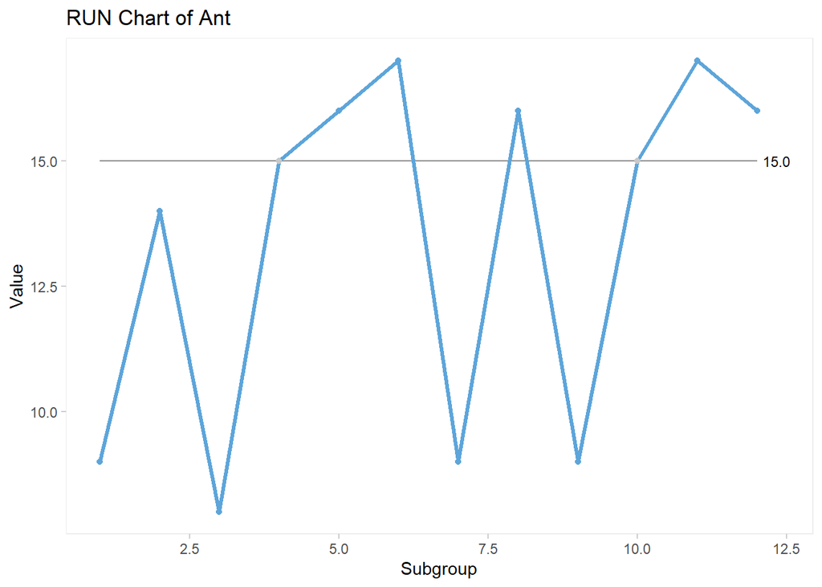

Teste skift i prosessen: Er ant etterfølgende pkt på ei side mer enn: 6? Nei. Er ant skift/kryssinger færre enn: 2? Nei.

## Spm 2. Forskjell i andel utskriving mellom aldersgrupper

I aldergruppa 0-9 år vart det skrive ut 20 pasientar på vakttid, og det var 47,6% av alle utskrivingar i den aldersgruppa. I andre enden var det 7 pasientar i alderen 80-89 som vart utskrivne på vakttid, og det utgjorde 18,9% av alle utskrivingane i den aldersgruppa. Det ser her ut til å vere tydelege skilnader i andelar som vert utskrivne på vakttid. Er det statistisk signifikant?

```
##
##  9-sample test for equality of proportions without continuity correction
##
## data:  AntAldGrVakt out of AntAldGrTot
## X-squared = 13.334, df = 8, p-value = 0.1009
## alternative hypothesis: two.sided
## sample estimates:
##    prop 1    prop 2    prop 3    prop 4    prop 5    prop 6    prop 7    prop 8
## 0.4761905 0.2307692 0.3666667 0.3939394 0.2558140 0.3823529 0.3043478 0.2689076
##    prop 9
## 0.1891892
```

```
##
##  Exact two-sample Kolmogorov-Smirnov test
##
## data:  AntAldGrVakt and AntAldGrTot - AntAldGrVakt
## D = 0.55556, p-value = 0.09872
## alternative hypothesis: two-sided
```

Test for ulike andeler gir p-verdi: 0.1008669

Vi kan også benytte en Kolmogorov-Smirnoftest for å teste om det er forskjell i fordeling for overførte i og utenfor vakttid. P-verdi: 0.0987248

Begge tester konkluderer med at det ikke er signifikante avvik i andelene hvis vi velger 5% konfidensnivå. Med 10% er vi akkurat i grenseland..

## Spm. 3. Er det signifikante kjønnsskilnader i andelar som er utskrivne på vakttid/dagtid

Av i alt 297 utskrivne menn, vart 89 (30,0%) utskrivne på vakttid, og 208 (70%) på dagtid Av i alt 216 utskrivne kvinner, vart 72 (33,3%) utskriven på vakttid, og 144 (66,7%) på dagtid.

Eg finn med mine enkle utrekningar at dette ikkje representerer nokon signifikant skilnad, men vil gjerne ha det kontrollert og stadfesta av ein statistikar.

```
##
##  2-sample test for equality of proportions with continuity correction
##
## data:  KjVakt out of KjTOt
## X-squared = 0.51126, df = 1, p-value = 0.4746
## alternative hypothesis: two.sided
## 95 percent confidence interval:
##  -0.11931734  0.05197727
## sample estimates:
##    prop 1    prop 2
## 0.2996633 0.3333333
```

Testen gir en p-verdi på 0.4745926, så absolutt ikke signifikant.

Eg trur ikkje det har noko for seg å sjå på ev. kjønnsskilnader i dei ulike aldersgruppene i tillegg – kva seier du til det?

Enig, det er ikke veldig store forskjeller og blir små grupper.